# Part II: Data analysis

[figure not shown]

In this section we'll learn:

- How to obtain simple insights from the data
- How to generate simple plots
- Groupping data and computing aggregates
- Basic time series operations

```python
import os
import pandas

#movies = pandas.read_json(os.path.join('data', 'movies_clean.jsonl.bz2'), lines=True).set_index('imdb_id')

movies = pandas.read_json('movies_clean.jsonl.bz2', lines=True).set_index('imdb_id')
```

```python
movies.head()
```

| imdb_id | cast | certificate | color | country | genres | gross | language | num_ratings | photo | plot_keywords | production_co | rate | release_date | runtime | storyline | summary | title | year |
| --- | --- | --- | --- | --- | --- | --- | --- | --- | --- | --- | --- | --- | --- | --- | --- | --- | --- | --- |
| tt5474036 | [{'imdb_id': 'nm3966456', 'name': 'Tapsee Pann... | 12A\|\n » | Color | [India] | [Romance] | 5.0 | [Hindi] | 1756.0 | https://m.media-amazon.com/images/M/MV5BNTU3Zj... | None | [Colour Yellow Productions] | 7.0 | 1.536883e+12 | 156.0 | The film is a love story set in Punjab where A... | The film is a love story set in Punjab where A... | Husband Material | 2018.0 |
| tt5970844 | [{'imdb_id': 'nm0451148', 'name': 'Aamir Khan'... | None | Color | [India] | [Action, Adventure] | NaN | [Hindi, Tamil, Telugu] | NaN | https://m.media-amazon.com/images/M/MV5BMTA3OD... | [based on novel] | [] | NaN | 1.541635e+12 | NaN | None | None | Thugs of Hindostan | 2018.0 |
| tt8108202 | [{'imdb_id': 'nm3822770', 'name': 'Rajkummar R... | 15\|\n » | Color | [India] | [Comedy, Horror] | NaN | [Hindi] | 7531.0 | https://m.media-amazon.com/images/M/MV5BMjk4NG... | [father son relationship, friendship, prostitu... | [D2R Films] | 8.3 | 1.535674e+12 | 128.0 | Chanderi village is haunted for years by a wit... | In the small town of Chanderi, the menfolk liv... | Stree | 2018.0 |
| tt7720922 | [{'imdb_id': 'nm1372788', 'name': 'Shahid Kapo... | PG\|\n » | Color | [India] | [Drama] | 1.0 | [Hindi] | 1410.0 | https://m.media-amazon.com/images/M/MV5BNzdiNW... | None | [Krti Pictures] | 6.4 | 1.537488e+12 | 161.0 | S.K, Nauti, and Tripathi are childhood friends... | A social movie about escalating electric bills. | Batti Gul Meter Chalu | 2018.0 |
| tt5080556 | [{'imdb_id': 'nm0707425', 'name': 'Rajinikanth... | None | Color | [India] | [Action, Sci-Fi, Thriller] | NaN | [Tamil, Telugu, Hindi] | NaN | https://m.media-amazon.com/images/M/MV5BZDE4MG... | [sequel, robot] | [Dakshaa] | NaN | 1.543450e+12 | NaN | Dr. Vaseegaran is forced to reassemble Chitti ... | Dr. Vaseegaran is forced to reassemble Chitti ... | 2.0 | 2018.0 |

```python
movies.tail()
```

| imdb_id | cast | certificate | color | country | genres | gross | language | num_ratings | photo | plot_keywords | production_co | rate | release_date | runtime | storyline | summary | title | year |
| --- | --- | --- | --- | --- | --- | --- | --- | --- | --- | --- | --- | --- | --- | --- | --- | --- | --- | --- |
| tt9046206 | [{'imdb_id': 'nm10148511', 'name': 'Madhu Sing... | None | Color | [India] | [Drama] | NaN | [Hindi] | NaN | https://m.media-amazon.com/images/M/MV5BNWFiMG... | None | None | NaN | 1.545955e+12 | NaN | None | None | Pariwar ae babu | 2018.0 |
| tt9052958 | [] | None | Color | [India] | None | NaN | [Hindi] | NaN | None | None | [] | NaN | NaN | NaN | Movie is adaptation of the epic Ramayana. | Movie is adaptation of the epic Ramayana. | Ramyug | 2019.0 |
| tt9052964 | [{'imdb_id': 'nm0332871', 'name': 'Govinda', '... | None | Color | [India] | [Comedy] | NaN | [Hindi] | NaN | None | None | [] | NaN | NaN | NaN | None | None | Rangeela Raja | 2018.0 |
| tt9053392 | [] | None | Color | [India] | [Action] | NaN | [Hindi] | NaN | None | None | None | NaN | NaN | NaN | None | None | Rannbhoomi | 2020.0 |
| tt9060700 | [{'imdb_id': 'nm10150444', 'name': 'Krishna Ga... | None | Color | [India] | [Drama] | NaN | [Hindi] | NaN | None | None | [Golden Triangle Charity Trust, Sylph Producti... | NaN | NaN | 90.0 | None | None | The Check Post | 2019.0 |

```python
movies.sort_values('rate', ascending=False).head(10)[['title', 'rate', 'num_ratings', 'release_date']]
```

[output not shown]

### Highest rated movies

Back from our previous example, let us see which are the highest rated movies.

We can easily sort our data by a column with the `DataFrame.sort_values()` method. It takes a boolean argument `ascending`.

**Exercise:** Get the top 10 rated movies.

```python
%timeit movies.nlargest(10, 'rate')
```

```
4.96 ms ± 24.1 µs per loop (mean ± std. dev. of 7 runs, 100 loops each)
```

`pandas` provides the method `.nlargest()` to perform this operation. The reason, is that sorting a large `DataFrame`, just to find the top 10 values is very inefficient.

**Exercise:** Obtain again the top 10 rated movies, this time with `.nlargest()`. And compare the difference of time between them. Jupyter provides the magic `%timeit` that display how long a line of code takes.

```python
movies['num_ratings'].describe()
```

```
count      5609.000000
mean       1866.771617
std       12248.980281
min           5.000000
25%          18.000000
50%          68.000000
75%         521.000000
max      722712.000000
Name: num_ratings, dtype: float64
```

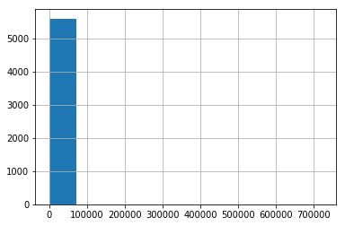

```python
%matplotlib inline
movies['num_ratings'].hist()
```

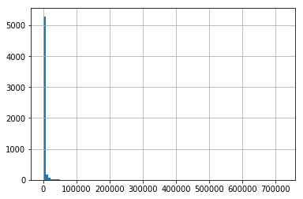

```python
movies['num_ratings'].hist(bins=100)
```

```python
movies[['rate', 'num_ratings']].corr()
```

|  | rate | num_ratings |
| --- | --- | --- |
| rate | 1.000000 | 0.127945 |
| num_ratings | 0.127945 | 1.000000 |

[figure not shown]

```python
movies.plot(kind='scatter', x='num_ratings', y='rate')
```

Did you watch any of them? Do you think are the best Bollywood movies of history?

Something interesting is that not so many people voted for them. So the rating is based in the opinions of not many people. In this dataset, how many votes is it "normal" to have for a movie?

**Exercises:**

- Get some statistics about the number of votes (min, max, median, mean, quantiles...)
- Plot a histogram with the distribution (pandas provides the method `Series.hist()` to plot histograms). Change the number of `bins` and see how it changes.

```python
movies.nlargest(5, 'num_ratings')
```

| imdb_id | cast | certificate | color | country | genres | gross | language | num_ratings | photo | plot_keywords | production_co | rate | release_date | runtime | storyline | summary | title | year |
| --- | --- | --- | --- | --- | --- | --- | --- | --- | --- | --- | --- | --- | --- | --- | --- | --- | --- | --- |
| tt1010048 | [{'imdb_id': 'nm2353862', 'name': 'Dev Patel',... | None | Color | [UK, USA, France, Germany, India] | [Drama, Romance] | 1.0 | [English, Hindi, French, German] | 722712.0 | https://m.media-amazon.com/images/M/MV5BZmNjZW... | [india, television show, contestant, underdog,... | [Warner Bros., Celador Films] | 8.0 | 1.230163e+12 | 120.0 | The story of Jamal Malik, an 18 year-old orpha... | A Mumbai teen reflects on his upbringing in th... | Slumdog Millionaire | 2008.0 |
| tt1187043 | [{'imdb_id': 'nm0451148', 'name': 'Aamir Khan'... | None | Color | [India] | [Comedy, Drama] | 6.0 | [Hindi, English] | 282048.0 | https://m.media-amazon.com/images/M/MV5BNTkyOG... | [bollywood, against the system, suicide, suici... | [] | 8.4 | 1.261613e+12 | 170.0 | Farhan Qureshi and Raju Rastogi want to re-uni... | Two friends are searching for their long lost ... | 3 Idiots | 2009.0 |
| tt0986264 | [{'imdb_id': 'nm2594301', 'name': 'Darsheel Sa... | None | Color | [India] | [Drama, Family] | 1.0 | [Hindi, English] | 129723.0 | https://m.media-amazon.com/images/M/MV5BNTVmYT... | [dyslexia, dream, intolerance, special educati... | [Aamir Khan Productions] | 8.4 | 1.198195e+12 | 165.0 | Ishaan Awasthi is an eight-year-old child whos... | An eight-year-old boy is thought to be a lazy ... | Like Stars on Earth | 2007.0 |
| tt2338151 | [{'imdb_id': 'nm0451148', 'name': 'Aamir Khan'... | Not Rated\|\n » | Color | [India] | [Comedy, Drama] | 1.0 | [Hindi, English, Urdu, Persian, Kurdish] | 127507.0 | https://m.media-amazon.com/images/M/MV5BMTYzOT... | [religion, letter in title, indian, indian abr... | [Rajkumar Hirani Films] | 8.2 | 1.418947e+12 | 153.0 | P. K. is a comedy of ideas about a stranger in... | An alien on Earth loses the only device he can... | PK | 2014.0 |
| tt5074352 | [{'imdb_id': 'nm0451148', 'name': 'Aamir Khan'... | Not Rated\|\n » | Color | [India] | [Action, Biography, Drama, Sport] | 1.0 | [Hindi, Tamil, Telugu] | 105171.0 | https://m.media-amazon.com/images/M/MV5BMTQ4Mz... | [small town, father daughter relationship, mal... | [Aamir Khan Productions, UTV Motion Pictures] | 8.5 | 1.482278e+12 | 140.0 | Biopic of | Former wrestler | Dangal | 2016.0 |

[figure not shown]

```python
movies.set_index('release_date')['runtime'].plot()
```

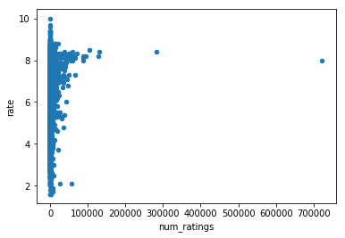

```python
movies.plot(kind='scatter', x='num_ratings', y='rate')
```

What we are interested, is to know whether there is a correlation between the rating and the number of people who rated the movie. To see how they are related we can analyze the correlation, and we can plot both variables.

**Exercises:**

- Compute the correlation between the two variables (`DataFrame.corr()` computes the correlation among all the columns in a `DataFrame`).
- Generate a scatter plot with the data (`pandas` provides many plots, in most cases we want to use the method `.plot(kind=kind)` where `kind` can be `line`, `bar`, `barh`, `scatter`...).
- Which are the movies that have very large number of ratings?
- Generate the scatter plot without these values. `Series.quantile()` is used often to detect extreme values, as it can report the value containing for example 95% of the samples.

### Movie duration over time

Let us analyze something different now. The question is, whether the duration of Bollywood changed over time, and in which way.

We have already seen, that plotting data can help find answers to our questions.

**Exercise:** Plot the duration of the movie as a function of the release date of the movie. In this case, it can be useful to plot a line plot. For line plots we usually set the column we want in the `x` axis of the plot as the index. The columns of the `DataFrame` will be plotted as lines.

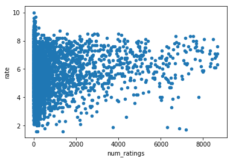

```python
movies[movies.num_ratings < movies.num_ratings.quantile(.95)].plot(kind='scatter', x='num_ratings', y='rate')
```

Plotting with the original granularity (one point per movie) can be very noise. But `pandas` can easily aggregate data, including time series data. To change the frequency of the data, `DataFrame.resample` exists. `reample` receives a parameter with the new frequency, for example `D` for day, `M` for month, `Q` for quarter, and more specific frequencies like `2M` for 2 months can be used. The result of `resample` is a `GroupBy` object, and we need to specify the aggregate function that we want to use on it, for example `mean`, `median`...

**Exercise:** Resample the `release_date` to a quarter frequency, and plot the median of the runtime over it.

```python
movies.set_index('release_date').resample('Q')['runtime'].median().plot()
```

[output not shown]

Similar to `resample`, `pandas` provides a `groupby` method that can group discrete values, for example strings. The syntax is similar, but the column to group by is not expected to be the index, and to specify which of the columns to group by, we provide the name as a parameter: `movies.groupby(column_to_group_by)`.

**Exercise:** Group the data by the column color, and check whether in average color movies are longer or shorter than black and white movies.

```python
movies.groupby('color')['runtime'].median()
```

```
color
Black and White    125.0
Color              133.0
Name: runtime, dtype: float64
```